# Reproducible Research: Peer Assessment 1

Jane Pouzou

```r
activity=read.csv('./activity/activity.csv')
str(activity)
```

```
## 'data.frame':    17568 obs. of  3 variables:
##  $ steps   : int  NA NA NA NA NA NA NA NA NA NA ...
##  $ date    : chr  "2012-10-01" "2012-10-01" "2012-10-01" "2012-10-01" ...
##  $ interval: int  0 5 10 15 20 25 30 35 40 45 ...
```

```r
table(is.na(activity$steps))
```

```
##
## FALSE  TRUE
## 15264  2304
```

```r
activity$date=as.Date.character(activity$date)
```

Step 2: What is mean total number of steps taken per day?

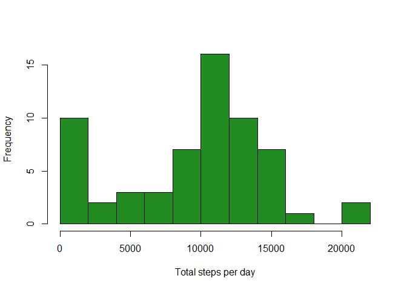

```r
dailysteps=aggregate(activity$steps, by=list(activity$date), sum, na.rm=TRUE)
hist(dailysteps$x, breaks=10, col="forestgreen", xlab="Total steps per day", main="")
```

```r
#Mean is
mean(dailysteps$x, na.rm=TRUE)
```

```
## [1] 9354.23
```

```r
#Mean is
median(dailysteps$x, na.rm=TRUE)
```

```
## [1] 10395
```

Step 3: What is the average daily activity pattern?

Time-series plot of steps per interval averaged across all days.

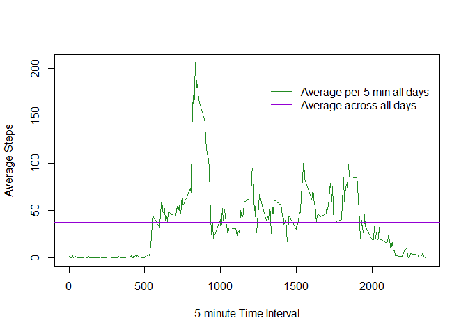

```r
intervalsteps=aggregate(activity$steps, by=list(activity$interval), mean, na.rm=TRUE)
plot(intervalsteps$x~intervalsteps$Group.1, type="l", ylab="Average Steps", xlab="5-minute Time Interval", col="forestgreen")
abline(h=mean(intervalsteps$x), col="darkviolet")
legend(1270, 190, legend=c("Average per 5 min all days", "Average across all days"), col=c("forestgreen", "darkviolet"), lty=1, box.lty=0)
```

```r
# Which 5-minute interval, on average across all the days in the dataset, contains the maximum number of steps?
unique(intervalsteps$Group.1[intervalsteps$x==max(intervalsteps$x, na.rm=TRUE)])
```

```
## [1] 835
```

Step 4: Imputing missing values

Note that there are a number of days/intervals where there are missing values (coded as `NA`). The presence of missing days may introduce bias into some calculations or summaries of the data.

1. Calculate and report the total number of missing values in the dataset (i.e. the total number of rows with `NA`s)

```r
table(is.na(activity$steps))
```

```
##
## FALSE  TRUE
## 15264  2304
```

2. Devise a strategy for filling in all of the missing values in the dataset. The strategy does not need to be sophisticated. For example, you could use the mean/median for that day, or the mean for that 5-minute interval, etc.
3. Create a new dataset that is equal to the original dataset but with the missing data filled in.

```r
activity2=merge(activity, intervalsteps, by.x=c("interval"), by.y=c("Group.1"), all.x=TRUE)
activity2$steps[is.na(activity2$steps)]=round(activity2$x[is.na(activity2$steps)], 0)
```

4. Make a histogram of the total number of steps taken each day and Calculate and report the **mean** and **median** total number of steps taken per day.

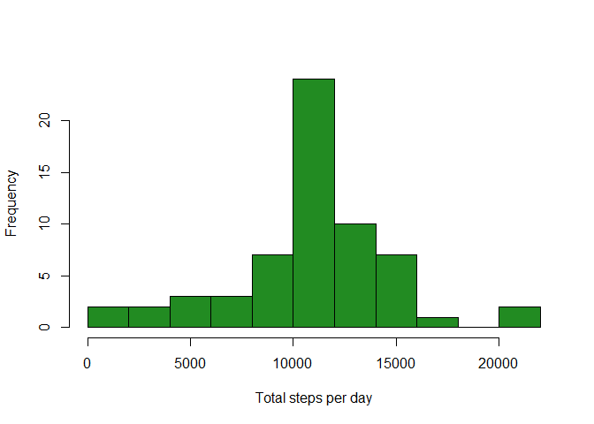

```r
dailysteps2=aggregate(activity2$steps, by=list(activity2$date), sum, na.rm=TRUE)
hist(dailysteps2$x, breaks=10, col="forestgreen", xlab="Total steps per day", main="")
```

```r
#Mean is
mean(dailysteps2$x, na.rm=TRUE)
```

```
## [1] 10765.64
```

```r
#Mean is
median(dailysteps2$x, na.rm=TRUE)
```

```
## [1] 10762
```

Do these values differ from the estimates from the first part of the assignment? What is the impact of imputing missing data on the estimates of the total daily number of steps?

Step 5: Are there differences in activity patterns between weekdays and weekends?

1. Create a new factor variable in the dataset with two levels – “weekday” and “weekend” indicating whether a given date is a weekday or weekend day.

```r
activity2$weekend="weekday"
activity2$weekend[weekdays(activity2$date)%in%c("Saturday", "Sunday")]="weekend"
```

2. Make a panel plot containing a time series plot (i.e. `type = "l"`) of the 5-minute interval (x-axis) and the average number of steps taken, averaged across all weekday days or weekend days (y-axis).

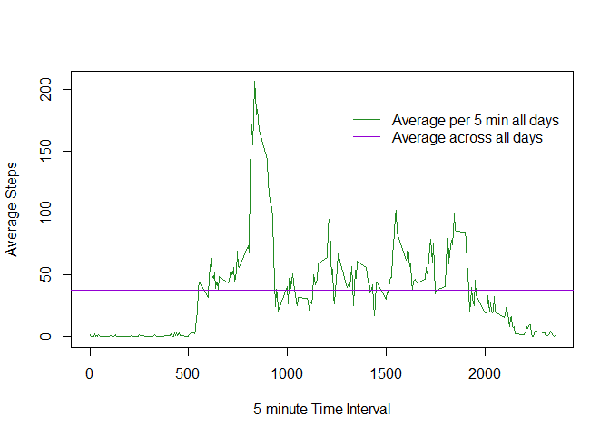

```r
intervalsteps2=aggregate(activity2$steps, by=list(activity2$interval, activity2$weekend), mean,   na.rm=TRUE)
  plot(intervalsteps$x~intervalsteps$Group.1, type="l", ylab="Average Steps", xlab="5-minute Time Interval", col="forestgreen")
    abline(h=mean(intervalsteps$x), col="darkviolet")
    legend(1270, 190, legend=c("Average per 5 min all days", "Average across all days"), col=c("forestgreen", "darkviolet"), lty=1, box.lty=0)
```

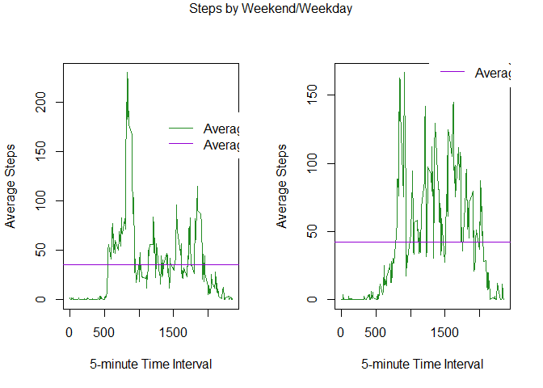

```r
par(mfrow = c(1, 2))
plot(intervalsteps2$x[intervalsteps2$Group.2=="weekday"]~intervalsteps2$Group.1[intervalsteps2$Group.2=="weekday"], type="l", ylab="Average Steps", xlab="5-minute Time Interval", col="forestgreen")
  abline(h=mean(intervalsteps2$x[intervalsteps2$Group.2=="weekday"]), col="darkviolet")
  legend(1270, 190, legend=c("Average per 5 min all days", "Average across all days"), col=c("forestgreen", "darkviolet"), lty=1, box.lty=0)
plot(intervalsteps2$x[intervalsteps2$Group.2=="weekend"]~intervalsteps2$Group.1[intervalsteps2$Group.2=="weekend"], type="l", ylab="Average Steps", xlab="5-minute Time Interval", col="forestgreen")
  abline(h=mean(intervalsteps2$x[intervalsteps2$Group.2=="weekend"]), col="darkviolet")
  legend(1270, 190, legend=c("Average per 5 min all days", "Average across all days"), col=c("forestgreen", "darkviolet"), lty=1, box.lty=0)
mtext("Steps by Weekend/Weekday", side=3, outer=T, line=-1)
```